# INN Hotels Project

#### Visualizing the Decision Tree

```python
feature_names = list(X_train.columns)
importances = estimator.feature_importances_
indices = np.argsort(importances)
```

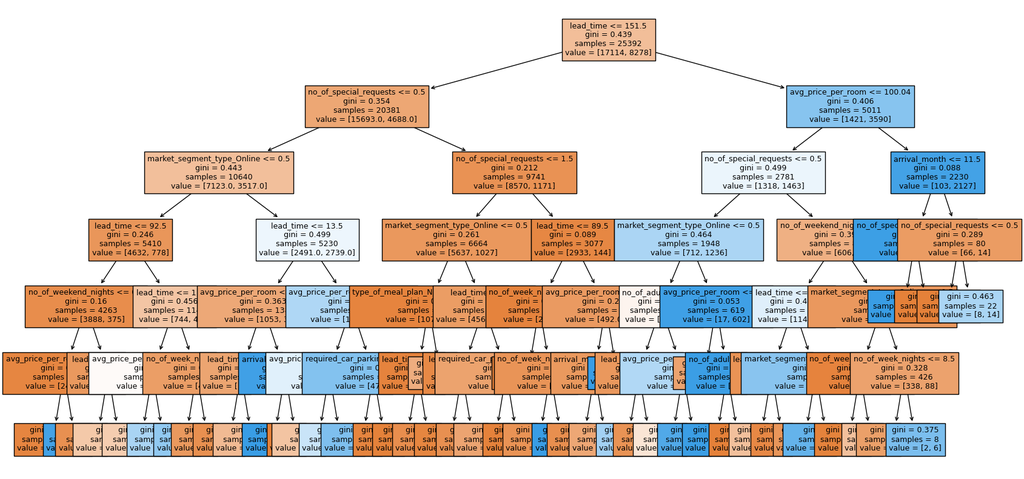

```python
plt.figure(figsize=(20, 10))
out = tree.plot_tree(
    estimator,
    feature_names=feature_names,
    filled=True,
    fontsize=9,
    node_ids=False,
    class_names=None,
)
# below code will add arrows to the decision tree split if they are missing
for o in out:
    arrow = o.arrow_patch
    if arrow is not None:
        arrow.set_edgecolor("black")
        arrow.set_linewidth(1)
plt.show()
```

```python
# Text report showing the rules of a decision tree -
print(tree.export_text(estimator, feature_names=feature_names, show_weights=True))
```

```
|--- lead_time <= 151.50
|   |--- no_of_special_requests <= 0.50
|   |   |--- market_segment_type_Online <= 0.50
|   |   |   |--- lead_time <= 92.50
|   |   |   |   |--- no_of_weekend_nights <= 0.50
|   |   |   |   |   |--- avg_price_per_room <= 201.50
|   |   |   |   |   |   |--- weights: [2424.00, 84.00] class: 0
|   |   |   |   |   |--- avg_price_per_room >  201.50
|   |   |   |   |   |   |--- weights: [1.00, 18.00] class: 1
|   |   |   |   |--- no_of_weekend_nights >  0.50
|   |   |   |   |   |--- lead_time <= 65.50
|   |   |   |   |   |   |--- weights: [1250.00, 152.00] class: 0
|   |   |   |   |   |--- lead_time >  65.50
|   |   |   |   |   |   |--- weights: [213.00, 121.00] class: 0
|   |   |   |--- lead_time >  92.50
|   |   |   |   |--- lead_time <= 116.50
|   |   |   |   |   |--- avg_price_per_room <= 91.22
|   |   |   |   |   |   |--- weights: [220.00, 132.00] class: 0
|   |   |   |   |   |--- avg_price_per_room >  91.22
|   |   |   |   |   |   |--- weights: [98.00, 174.00] class: 1
|   |   |   |   |--- lead_time >  116.50
|   |   |   |   |   |--- no_of_week_nights <= 0.50
|   |   |   |   |   |   |--- weights: [8.00, 18.00] class: 1
|   |   |   |   |   |--- no_of_week_nights >  0.50
|   |   |   |   |   |   |--- weights: [418.00, 79.00] class: 0
|   |   |--- market_segment_type_Online >  0.50
|   |   |   |--- lead_time <= 13.50
|   |   |   |   |--- avg_price_per_room <= 202.67
|   |   |   |   |   |--- lead_time <= 2.50
|   |   |   |   |   |   |--- weights: [528.00, 62.00] class: 0
|   |   |   |   |   |--- lead_time >  2.50
|   |   |   |   |   |   |--- weights: [524.00, 238.00] class: 0
|   |   |   |   |--- avg_price_per_room >  202.67
|   |   |   |   |   |--- arrival_month <= 11.50
|   |   |   |   |   |   |--- weights: [0.00, 29.00] class: 1
|   |   |   |   |   |--- arrival_month >  11.50
|   |   |   |   |   |   |--- weights: [1.00, 0.00] class: 0
|   |   |   |--- lead_time >  13.50
|   |   |   |   |--- avg_price_per_room <= 111.76
|   |   |   |   |   |--- avg_price_per_room <= 72.22
```

[output cut: 87 more lines]

```
|   |   |   |   |   |--- no_of_week_nights <= 8.50
|   |   |   |   |   |   |--- weights: [336.00, 82.00] class: 0
|   |   |   |   |   |--- no_of_week_nights >  8.50
|   |   |   |   |   |   |--- weights: [2.00, 6.00] class: 1
|   |--- avg_price_per_room >  100.04
|   |   |--- arrival_month <= 11.50
|   |   |   |--- no_of_special_requests <= 2.50
|   |   |   |   |--- weights: [0.00, 2113.00] class: 1
|   |   |   |--- no_of_special_requests >  2.50
|   |   |   |   |--- weights: [37.00, 0.00] class: 0
|   |   |--- arrival_month >  11.50
|   |   |   |--- no_of_special_requests <= 0.50
|   |   |   |   |--- weights: [58.00, 0.00] class: 0
|   |   |   |--- no_of_special_requests >  0.50
|   |   |   |   |--- weights: [8.00, 14.00] class: 1
```

```python
importances = estimator.feature_importances_
importances
```

```
array([0.        , 0.02328543, 0.        , 0.01467641, 0.0059224 ,
       0.00885259, 0.46633131, 0.        , 0.01958466, 0.        ,
       0.        , 0.        , 0.        , 0.13626545, 0.13389918,
       0.        , 0.        , 0.00048056, 0.        , 0.        ,
       0.        , 0.        , 0.        , 0.        , 0.        ,
       0.        , 0.        , 0.19070202])
```

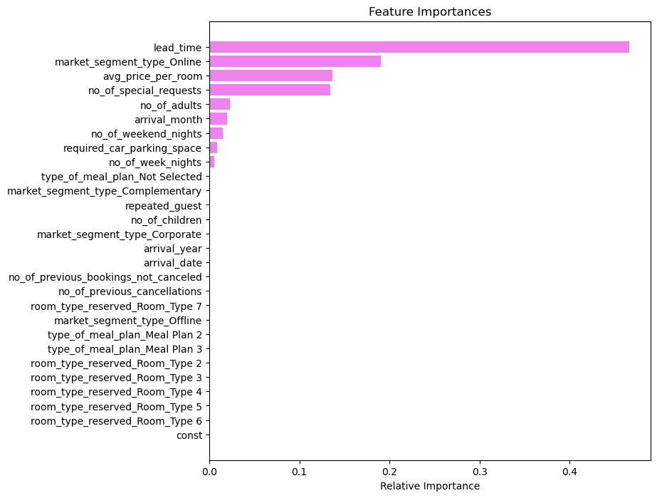

```python
# Importance of features in the tree building

importances = estimator.feature_importances_
indices = np.argsort(importances)

plt.figure(figsize=(8, 8))
plt.title("Feature Importances")
plt.barh(range(len(indices)), importances[indices], color="violet", align="center")
plt.yticks(range(len(indices)), [feature_names[i] for i in indices])
plt.xlabel("Relative Importance")
plt.show()
```

In the pre-pruned Decision Tree model, lead time is still the most important feature, but this time market_segment_type_Online is the second most important feature.

### Decision Tree (Post Pruning)

```python
clf = DecisionTreeClassifier(random_state = 42, class_weight="balanced")
path = clf.cost_complexity_pruning_path(X_train, y_train)
ccp_alphas, impurities = abs(path.ccp_alphas), path.impurities
```

```python
pd.DataFrame(path)
```

|  | ccp_alphas | impurities |
| --- | --- | --- |
| 0 | 0.00000 | 0.00855 |
| 1 | -0.00000 | 0.00855 |
| 2 | 0.00000 | 0.00855 |
| 3 | 0.00000 | 0.00855 |
| 4 | 0.00000 | 0.00855 |
| ... | ... | ... |
| 1574 | 0.00904 | 0.32867 |
| 1575 | 0.01017 | 0.33884 |
| 1576 | 0.01199 | 0.35084 |
| 1577 | 0.03448 | 0.41979 |
| 1578 | 0.08021 | 0.50000 |

1579 rows × 2 columns

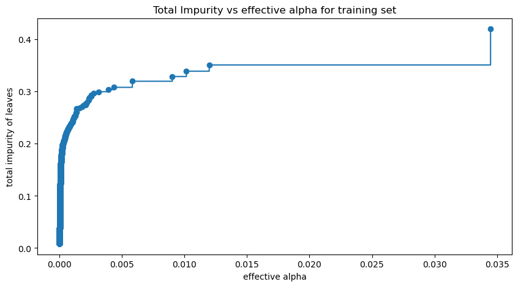

```python
fig, ax = plt.subplots(figsize=(10, 5))
ax.plot(ccp_alphas[:-1], impurities[:-1], marker="o", drawstyle="steps-post")
ax.set_xlabel("effective alpha")
ax.set_ylabel("total impurity of leaves")
ax.set_title("Total Impurity vs effective alpha for training set")
plt.show()
```

```python
clfs = []
for ccp_alpha in ccp_alphas:
    clf = DecisionTreeClassifier(
        random_state=42, ccp_alpha=ccp_alpha, class_weight="balanced"
    )
    clf.fit(X_train, y_train)
    clfs.append(clf)
print(
    "Number of nodes in the last tree is: {} with ccp_alpha: {}".format(
        clfs[-1].tree_.node_count, ccp_alphas[-1]
    )
)
```

```
Number of nodes in the last tree is: 1 with ccp_alpha: 0.08021206599375602
```

```python
f1_train = []
for clf in clfs:
    pred_train = clf.predict(X_train)
    values_train = f1_score(y_train, pred_train)
    f1_train.append(values_train)

f1_test = []
for clf in clfs:
    pred_test = clf.predict(X_test)
    values_test = f1_score(y_test, pred_test)
    f1_test.append(values_test)
```

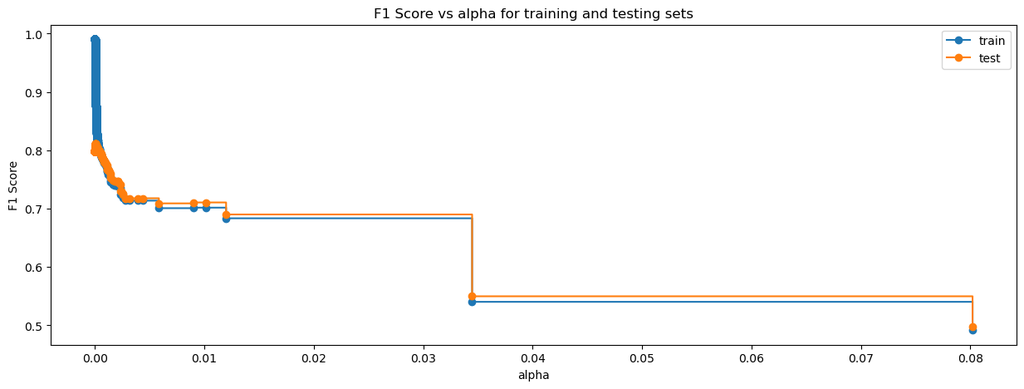

```python
fig, ax = plt.subplots(figsize=(15, 5))
ax.set_xlabel("alpha")
ax.set_ylabel("F1 Score")
ax.set_title("F1 Score vs alpha for training and testing sets")
ax.plot(ccp_alphas, f1_train, marker="o", label="train", drawstyle="steps-post")
ax.plot(ccp_alphas, f1_test, marker="o", label="test", drawstyle="steps-post")
ax.legend()
plt.show()
```

```python
# Creating the model where we get highest train and test recall
index_best_model = np.argmax(f1_test)
best_model = clfs[index_best_model]
print(best_model)
```

```
DecisionTreeClassifier(ccp_alpha=7.433902690207174e-05, class_weight='balanced',
                       random_state=42)
```

#### Checking performance of post pruned Decision Tree Model

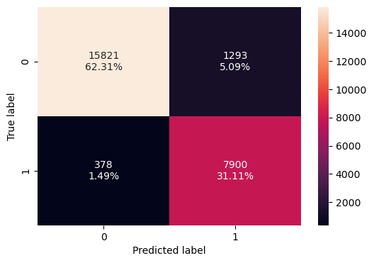

```python
confusion_matrix_sklearn(best_model, X_train, y_train)
```

```python
decision_tree_postprune_perf_train = model_performance_classification_sklearn(
    best_model, X_train, y_train
)
decision_tree_postprune_perf_train
```

|  | Accuracy | Recall | Precision | F1 |
| --- | --- | --- | --- | --- |
| 0 | 0.93419 | 0.95434 | 0.85935 | 0.90436 |

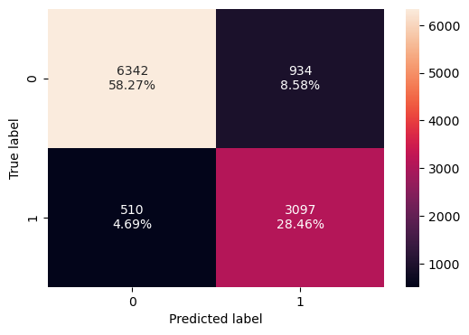

```python
confusion_matrix_sklearn(best_model, X_test, y_test)
```

```python
decision_tree_postprune_test = model_performance_classification_sklearn(
    best_model, X_test, y_test
)
decision_tree_postprune_test
```

|  | Accuracy | Recall | Precision | F1 |
| --- | --- | --- | --- | --- |
| 0 | 0.86732 | 0.85861 | 0.76830 | 0.81095 |

[figure not shown]

```python
plt.figure(figsize=(20, 10))

out = tree.plot_tree(
    best_model,
    feature_names=feature_names,
    filled=True,
    fontsize=9,
    node_ids=False,
    class_names=None,
)
for o in out:
    arrow = o.arrow_patch
    if arrow is not None:
        arrow.set_edgecolor("black")
        arrow.set_linewidth(1)
plt.show()
```

```python
# Text report showing the rules of a decision tree -
print(tree.export_text(best_model, feature_names=feature_names, show_weights=True))
```

```
|--- lead_time <= 151.50
|   |--- no_of_special_requests <= 0.50
|   |   |--- market_segment_type_Online <= 0.50
|   |   |   |--- lead_time <= 90.50
|   |   |   |   |--- no_of_weekend_nights <= 0.50
|   |   |   |   |   |--- avg_price_per_room <= 201.50
|   |   |   |   |   |   |--- market_segment_type_Corporate <= 0.50
|   |   |   |   |   |   |   |--- market_segment_type_Offline <= 0.50
|   |   |   |   |   |   |   |   |--- avg_price_per_room <= 107.00
|   |   |   |   |   |   |   |   |   |--- weights: [78.64, 1.53] class: 0
|   |   |   |   |   |   |   |   |--- avg_price_per_room >  107.00
|   |   |   |   |   |   |   |   |   |--- weights: [5.19, 6.13] class: 1
|   |   |   |   |   |   |   |--- market_segment_type_Offline >  0.50
|   |   |   |   |   |   |   |   |--- weights: [1241.11, 0.00] class: 0
|   |   |   |   |   |   |--- market_segment_type_Corporate >  0.50
|   |   |   |   |   |   |   |--- repeated_guest <= 0.50
|   |   |   |   |   |   |   |   |--- room_type_reserved_Room_Type 4 <= 0.50
|   |   |   |   |   |   |   |   |   |--- lead_time <= 16.50
|   |   |   |   |   |   |   |   |   |   |--- avg_price_per_room <= 170.32
|   |   |   |   |   |   |   |   |   |   |   |--- truncated branch of depth 10
|   |   |   |   |   |   |   |   |   |   |--- avg_price_per_room >  170.32
|   |   |   |   |   |   |   |   |   |   |   |--- weights: [0.00, 1.53] class: 1
|   |   |   |   |   |   |   |   |   |--- lead_time >  16.50
|   |   |   |   |   |   |   |   |   |   |--- arrival_month <= 11.50
|   |   |   |   |   |   |   |   |   |   |   |--- truncated branch of depth 9
|   |   |   |   |   |   |   |   |   |   |--- arrival_month >  11.50
|   |   |   |   |   |   |   |   |   |   |   |--- weights: [19.29, 0.00] class: 0
|   |   |   |   |   |   |   |   |--- room_type_reserved_Room_Type 4 >  0.50
|   |   |   |   |   |   |   |   |   |--- no_of_adults <= 1.50
|   |   |   |   |   |   |   |   |   |   |--- lead_time <= 5.50
|   |   |   |   |   |   |   |   |   |   |   |--- weights: [2.97, 6.13] class: 1
|   |   |   |   |   |   |   |   |   |   |--- lead_time >  5.50
|   |   |   |   |   |   |   |   |   |   |   |--- weights: [15.58, 1.53] class: 0
|   |   |   |   |   |   |   |   |   |--- no_of_adults >  1.50
|   |   |   |   |   |   |   |   |   |   |--- arrival_month <= 6.50
|   |   |   |   |   |   |   |   |   |   |   |--- weights: [0.00, 15.34] class: 1
|   |   |   |   |   |   |   |   |   |   |--- arrival_month >  6.50
|   |   |   |   |   |   |   |   |   |   |   |--- weights: [1.48, 0.00] class: 0
|   |   |   |   |   |   |   |--- repeated_guest >  0.50
|   |   |   |   |   |   |   |   |--- weights: [114.24, 1.53] class: 0
```

[output cut: 861 more lines]

```
|   |   |   |   |   |--- weights: [114.24, 4.60] class: 0
|   |--- avg_price_per_room >  100.04
|   |   |--- arrival_month <= 11.50
|   |   |   |--- no_of_special_requests <= 2.50
|   |   |   |   |--- weights: [0.00, 3240.72] class: 1
|   |   |   |--- no_of_special_requests >  2.50
|   |   |   |   |--- weights: [27.45, 0.00] class: 0
|   |   |--- arrival_month >  11.50
|   |   |   |--- no_of_special_requests <= 0.50
|   |   |   |   |--- weights: [43.03, 0.00] class: 0
|   |   |   |--- no_of_special_requests >  0.50
|   |   |   |   |--- arrival_date <= 8.00
|   |   |   |   |   |--- weights: [2.23, 0.00] class: 0
|   |   |   |   |--- arrival_date >  8.00
|   |   |   |   |   |--- weights: [3.71, 21.47] class: 1
```

```python
importances = best_model.feature_importances_
indices = np.argsort(importances)
```

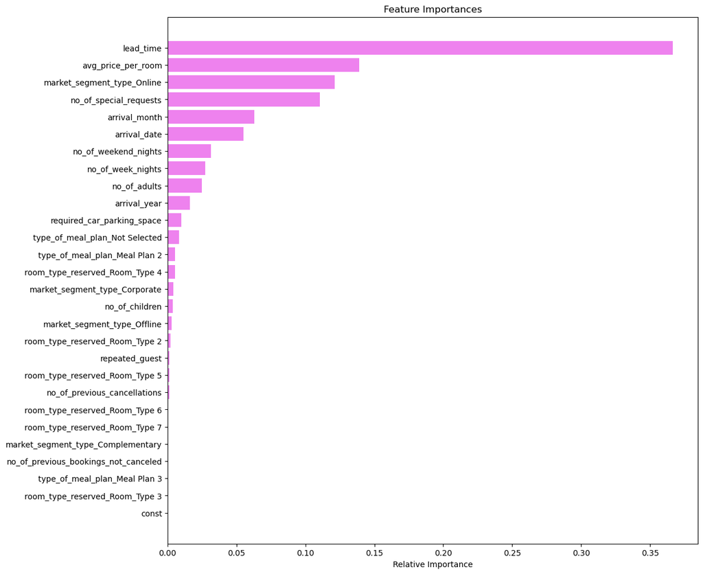

```python
plt.figure(figsize=(12, 12))
plt.title("Feature Importances")
plt.barh(range(len(indices)), importances[indices], color="violet", align="center")
plt.yticks(range(len(indices)), [feature_names[i] for i in indices])
plt.xlabel("Relative Importance")
plt.show()
```

## Model Performance Comparison and Conclusions

```python
# Training performance comparison

models_train_comp_df = pd.concat(
    [
        decision_tree_perf_train_without.T,
        decision_tree_perf_train.T,
        decision_tree_pretune_perf_train.T,
        decision_tree_postprune_perf_train.T,
    ],
    axis=1,
)
models_train_comp_df.columns = [
    "Decision Tree without class_weight",
    "Decision Tree with class_weight",
    "Decision Tree (Pre-Pruning)",
    "Decision Tree (Post-Pruning)",
]
print("Training performance comparison:")
models_train_comp_df
```

```
Training performance comparison:
```

|  | Decision Tree without class_weight | Decision Tree with class_weight | Decision Tree (Pre-Pruning) | Decision Tree (Post-Pruning) |
| --- | --- | --- | --- | --- |
| Accuracy | 0.99429 | 0.99366 | 0.84554 | 0.93419 |
| Recall | 0.98587 | 0.99360 | 0.69365 | 0.95434 |
| Precision | 0.99658 | 0.98704 | 0.80556 | 0.85935 |
| F1 | 0.99119 | 0.99031 | 0.74542 | 0.90436 |

```python
# Testing performance comparison

models_test_comp_df = pd.concat(
    [
        decision_tree_perf_test_without.T,
        decision_tree_perf_test.T,
        decision_tree_pretune_perf_test.T,
        decision_tree_postprune_test.T,
    ],
    axis=1,
)
models_test_comp_df.columns = [
    "Decision Tree without class_weight",
    "Decision Tree with class_weight",
    "Decision Tree (Pre-Pruning)",
    "Decision Tree (Post-Pruning)",
]
print("Test set performance comparison:")
models_test_comp_df
```

```
Test set performance comparison:
```

|  | Decision Tree without class_weight | Decision Tree with class_weight | Decision Tree (Pre-Pruning) | Decision Tree (Post-Pruning) |
| --- | --- | --- | --- | --- |
| Accuracy | 0.86649 | 0.86612 | 0.84269 | 0.86732 |
| Recall | 0.80510 | 0.80177 | 0.68423 | 0.85861 |
| Precision | 0.79475 | 0.79582 | 0.81158 | 0.76830 |
| F1 | 0.79989 | 0.79878 | 0.74248 | 0.81095 |

The best decision tree model is the Decision Tree (Pre-Pruning) due to its comparable performance metrics for both the train and test sets, particularly an F1 score of 74%. In contrast, the Decision Tree (Post-Pruning) shows a 10% disparity in F1 scores and a high training F1 score of 90%, indicating potential overfitting.

#### Comparing the best Logistic Regression (0.3662 Threshold) and Decision Tree (Pre-Pruning) Model

#### Accuracy:

The Decision Tree outperforms the Logistic Regression in both the training and test sets (0.85 vs 0.79 on train, 0.84 vs 0.79 on test), indicating that it is better at fitting the data.

#### Recall:

Logistic Regression has a higher recall on both the training and test sets (0.74 vs 0.69 on train, 0.73 vs 0.68 on test), which means it is better at identifying cancellations (i.e., fewer false negatives).

#### Precision:

The Decision Tree has better precision on both sets (0.81 vs 0.66 on test), meaning it is better at minimizing false positives.

#### F1 Score:

The Decision Tree has a higher F1 score on both the train and test sets (0.75 vs 0.70 on train, 0.74 vs 0.70 on test), suggesting a better balance between recall and precision, especially on the test set.

#### Conclusion

**In conclusion, since the Decision Tree (Pre-Pruning) has a higher F1 score on the test set (0.74248 vs 0.69924), it provides a better balance between recall and precision overall. This makes it the recommended model for predicting booking cancellations.**